# Использование протокола STP. Агрегирование каналов.

Администрирование локальных сетей

Ромицына А. Р.

Российский университет дружбы народов, Москва, Россия

30 марта 2026

# Информация

## Докладчик

- Ромицына Анастасия Романовна
- НПИбд-02-23 Студ. билет: 1132236132
- Российский университет дружбы народов
- 1132236132@pfur.ru

## Проблема: что будет без STP?

Широковещательный шторм — парализует сеть

Нестабильность MAC-таблицы

Резервные связи = риск петель

## Решение: STP (Spanning Tree Protocol)

Оставляет активным один путь

Остальные — блокирует (горячий резерв)

Автоматическое восстановление при обрыве

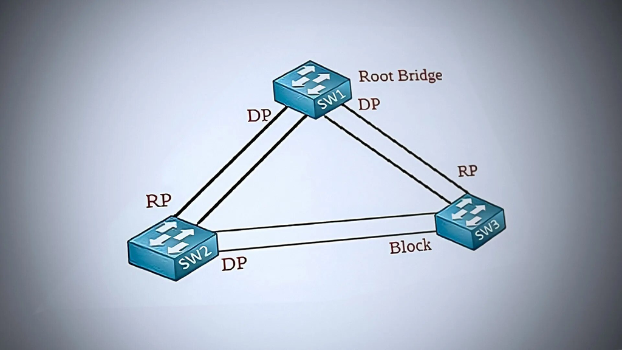

Spanning Tree Protocol

## Роли портов и состояния

Роль - Назначение Root Port - путь к корневому мосту Designated - пересылает в сегменте Alternate - заблокирован (запасной)

## Эволюция STP (какую версию брать?)

Версия Время перестройки STP (802.1D) до 50 сек RSTP (802.1w) 1–6 сек MSTP (802.1s) группы VLAN В современных сетях используем RSTP (быстро) или MSTP (экономит CPU)

## Защита от ошибок STP

BPDU Guard — блокирует порт с чужим коммутатором (для портов к ПК)

Root Guard — запрещает захват корневого моста

Loop Guard — защита при пропаже BPDU

## Агрегирование каналов (Link Aggregation)

Скорость = сумма портов (2 × 1 Гбит/с = 2 Гбит/с)

При отказе одного порта — остальные работают

Балансировка нагрузки по хэшу

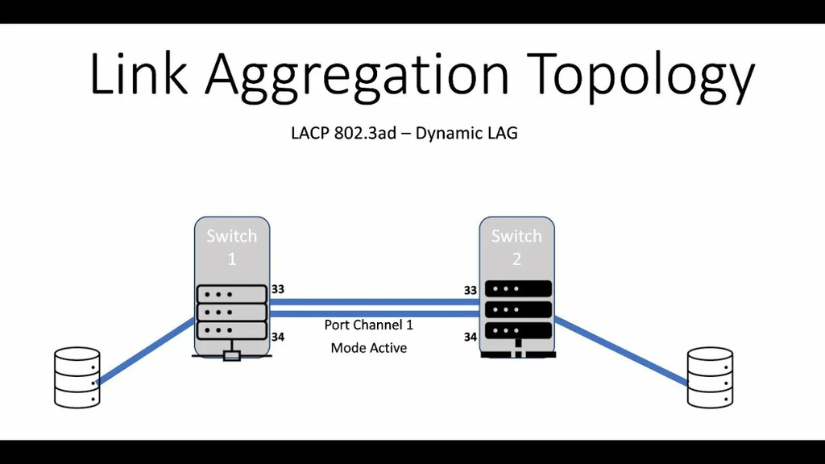

Link Aggregation

## LACP (802.3ad) — открытый стандарт

LACP — протокол переговоров

Устройства сами создают группу

Альтернатива: статический LAG (ручной)

## Балансировка нагрузки в LAG

Хэш от Когда использовать src-ip много клиентов dst-ip один сервер src-dst-ip универсально src-dst-port максимальная детализация

## Взаимодействие STP и LAG

STP блокирует / переводит весь LAG целиком

Добавление/удаление физического порта — без перестройки дерева

Резервный LAG можно держать заблокированным через STP

# Итоги

## Итоги

STP (RSTP/MSTP) — обязателен при резервных связях, иначе петли и коллапс сети.

Защитные механизмы (BPDU Guard, Root Guard) — стандарт безопасности.

LACP — увеличивает пропускную способность без изменения топологии.

STP + LAG работают вместе: LAG ускоряет, STP страхует от петель.